# Homework_2

## c

```r
lmod<-lm(Highway_mpg~Horsepower+Height+Length+Width+Torque+as.factor(Year), data=the_table_3)

summary(lmod)
```

```
##
## Call:
## lm(formula = Highway_mpg ~ Horsepower + Height + Length + Width +
##     Torque + as.factor(Year), data = the_table_3)
##
## Residuals:
##     Min      1Q  Median      3Q     Max
## -10.824  -2.550  -0.452   2.372 202.639
##
## Coefficients:
##                       Estimate Std. Error t value Pr(>|t|)
## (Intercept)         32.2926630  0.7225982  44.690  < 2e-16 ***
## Horsepower           0.0163556  0.0022772   7.182 7.96e-13 ***
## Height               0.0099079  0.0011267   8.794  < 2e-16 ***
## Length               0.0017290  0.0008836   1.957   0.0504 .
## Width               -0.0003343  0.0009045  -0.370   0.7117
## Torque              -0.0507425  0.0022030 -23.034  < 2e-16 ***
## as.factor(Year)2010 -0.4539681  0.6768246  -0.671   0.5024
## as.factor(Year)2011  0.1711016  0.6757043   0.253   0.8001
## as.factor(Year)2012  1.3029279  0.6810076   1.913   0.0558 .
## ---
## Signif. codes:  0 '***' 0.001 '**' 0.01 '*' 0.05 '.' 0.1 ' ' 1
##
## Residual standard error: 4.602 on 4582 degrees of freedom
## Multiple R-squared:  0.4192, Adjusted R-squared:  0.4182
## F-statistic: 413.3 on 8 and 4582 DF,  p-value: < 2.2e-16
```

## d

```r
cor(the_table_3$Horsepower, the_table_3$Torque)
```

```
## [1] 0.9474896
```

> The `cor()` helps to confirm that there is a correlation between the `Horsepower` and `Torque` variables.

```r
library(emmeans)
```

```r
summary(the_table_3$Horsepower)
```

```
##    Min. 1st Qu.  Median    Mean 3rd Qu.    Max.
##   100.0   185.0   263.0   267.5   317.0   638.0
```

```r
lmod_6<-lm(Highway_mpg ~ Horsepower*Torque+Height+Length+Width+as.factor(Year), data =the_table_3)
summary(lmod_6)
```

```
##
## Call:
## lm(formula = Highway_mpg ~ Horsepower * Torque + Height + Length +
##     Width + as.factor(Year), data = the_table_3)
##
## Residuals:
##     Min      1Q  Median      3Q     Max
## -11.109  -2.313  -0.258   2.062 203.540
##
## Coefficients:
##                       Estimate Std. Error t value Pr(>|t|)
## (Intercept)          4.219e+01  7.930e-01  53.199  < 2e-16 ***
## Horsepower          -1.666e-02  2.539e-03  -6.563 5.84e-11 ***
## Torque              -8.606e-02  2.533e-03 -33.972  < 2e-16 ***
## Height               6.560e-03  1.070e-03   6.133 9.32e-10 ***
## Length               1.777e-03  8.318e-04   2.136   0.0327 *
## Width               -1.169e-03  8.521e-04  -1.372   0.1700
## as.factor(Year)2010 -5.628e-01  6.372e-01  -0.883   0.3771
## as.factor(Year)2011  7.254e-02  6.361e-01   0.114   0.9092
## as.factor(Year)2012  1.197e+00  6.411e-01   1.867   0.0619 .
## Horsepower:Torque    1.124e-04  4.628e-06  24.276  < 2e-16 ***
## ---
## Signif. codes:  0 '***' 0.001 '**' 0.01 '*' 0.05 '.' 0.1 ' ' 1
##
## Residual standard error: 4.333 on 4581 degrees of freedom
## Multiple R-squared:  0.4854, Adjusted R-squared:  0.4844
## F-statistic: 480.1 on 9 and 4581 DF,  p-value: < 2.2e-16
```

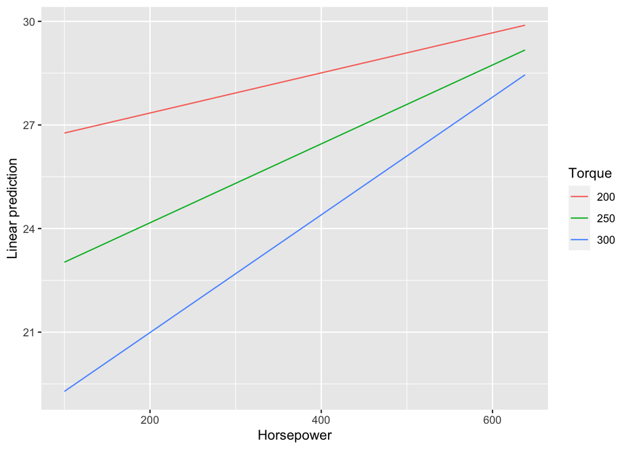

```r
emmip(lmod_6, Torque~Horsepower,at = list(Horsepower = c(100, 263, 638), Torque=c(200,250,300)))
```

## e

```r
beta<-lmod$coefficients

y<-the_table_3$Highway_mpg
X<-cbind(1, the_table_3$Horsepower, the_table_3$Torque, the_table_3$Horsepower*the_table_3$Torque)

# Using OLS formula to calculate beta
# It works on computers in school, but the R in my laptop can not run t() function, but this code is correct

beta_coef <-solve(t(X) %*% X) %*% t(X) %*% y


beta
```

```
##         (Intercept)          Horsepower              Height              Length
##       32.2926630057        0.0163556341        0.0099078942        0.0017289759
##               Width              Torque as.factor(Year)2010 as.factor(Year)2011
##       -0.0003343217       -0.0507424622       -0.4539681241        0.1711016371
## as.factor(Year)2012
##        1.3029279007
```

```r
beta_coef
```

```
##               [,1]
## [1,] 43.7868937169
## [2,] -0.0144854110
## [3,] -0.0910078462
## [4,]  0.0001159731
```

# Problem 3 Stata

## a

> Import the csv, and rename all variables

```stata
 import delimited cars
(encoding automatically selected: ISO-8859-1)
(18 vars, 5,076 obs)

. rename dimensionsheight height

. rename dimensionslength length

. rename dimensionswidth width

. rename v18 torque

. rename engineinformationtransmission transmission

. rename engineinformationdriveline driveline

. rename engineinformationenginestatistic horsepower

. rename fuelinformationhighwaympg highwaympg

. rename engineinformationenginetype enginetype

. rename engineinformationhybrid hybrid

. rename engineinformationnumberofforward numberofforward

. rename fuelinformationcitympg citympg

. rename fuelinformationfueltype fueltype

. rename identificationclassification classification

. rename identificationmodelyear modelyea

. rename modelyea modelyear

. rename identificationmake make

. rename identificationid ID

. rename identificationyear IDyear
```

## b

> Restrict all Fuel type tp be “Gasoline” by setting `if fueltype=="Gasoline"` as below.

## c

> Fit a linear regression model. The results are the same as in Problem 2(c)

```stata
reg highwaympg horsepower length width height torque i.IDyear if fueltype=="Gasoline"

      Source |       SS           df       MS      Number of obs   =     4,591
-------------+----------------------------------   F(8, 4582)      =    413.35
       Model |  70043.6695         8  8755.45869   Prob > F        =    0.0000
    Residual |   97055.298     4,582  21.1818634   R-squared       =    0.4192
-------------+----------------------------------   Adj R-squared   =    0.4182
       Total |  167098.968     4,590  36.4050038   Root MSE        =    4.6024

------------------------------------------------------------------------------
  highwaympg | Coefficient  Std. err.      t    P>|t|     [95% conf. interval]
-------------+----------------------------------------------------------------
  horsepower |   .0163556   .0022772     7.18   0.000     .0118913      .02082
      length |    .001729   .0008836     1.96   0.050    -3.36e-06    .0034613
       width |  -.0003343   .0009045    -0.37   0.712    -.0021075    .0014388
      height |   .0099079   .0011267     8.79   0.000      .007699    .0121168
      torque |  -.0507425    .002203   -23.03   0.000    -.0550614   -.0464236
             |
      IDyear |
       2010  |  -.4539681   .6768246    -0.67   0.502     -1.78087    .8729342
       2011  |   .1711016   .6757043     0.25   0.800    -1.153604    1.495808
       2012  |   1.302928   .6810076     1.91   0.056    -.0321751    2.638031
             |
       _cons |   32.29266   .7225982    44.69   0.000     30.87602     33.7093
------------------------------------------------------------------------------
```

## d

> Fit the regression again with interaction terms of torque and horsepower.

```stata
reg highwaympg torque horsepower c.horsepower#c.torque length width height i.IDyear if fueltype=="Gasoline"

      Source |       SS           df       MS      Number of obs   =     4,591
-------------+----------------------------------   F(9, 4581)      =    480.07
       Model |  81105.8715         9  9011.76351   Prob > F        =    0.0000
    Residual |   85993.096     4,581  18.7716865   R-squared       =    0.4854
-------------+----------------------------------   Adj R-squared   =    0.4844
       Total |  167098.968     4,590  36.4050038   Root MSE        =    4.3326

---------------------------------------------------------------------------------------
           highwaympg | Coefficient  Std. err.      t    P>|t|     [95% conf. interval]
----------------------+----------------------------------------------------------------
               torque |  -.0860593   .0025333   -33.97   0.000    -.0910257   -.0810928
           horsepower |  -.0166633   .0025388    -6.56   0.000    -.0216406    -.011686
                      |
c.horsepower#c.torque |   .0001124   4.63e-06    24.28   0.000     .0001033    .0001214
                      |
               length |   .0017767   .0008318     2.14   0.033     .0001459    .0034075
                width |  -.0011694   .0008521    -1.37   0.170      -.00284    .0005011
               height |   .0065604   .0010696     6.13   0.000     .0044634    .0086573
                      |
               IDyear |
                2010  |  -.5627858   .6371716    -0.88   0.377    -1.811949    .6863777
                2011  |   .0725356   .6361142     0.11   0.909    -1.174555    1.319626
                2012  |   1.197033   .6411085     1.87   0.062    -.0598488    2.453915
                      |
                _cons |   42.18795   .7930274    53.20   0.000     40.63323    43.74266
---------------------------------------------------------------------------------------
```

> The interaction plot is shown below

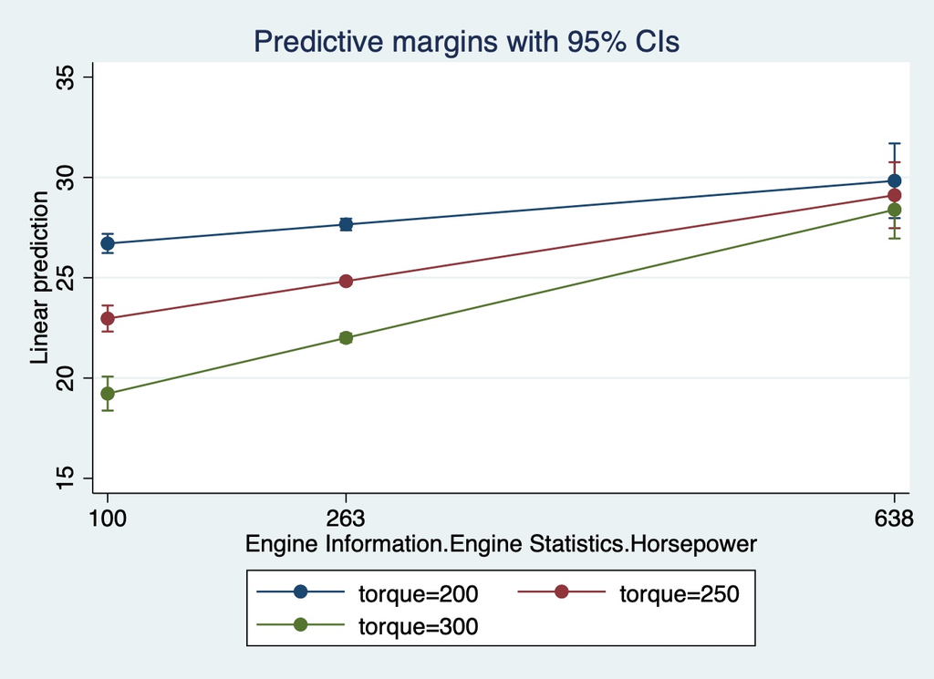

## e

```stata
    mkmat 1 torque horsepower horsepower*torque, matrix(X)

    mkmat highwaympg, matrix(y)

    X'*X*X'*y
```